# A Brief Tour of the Tour de France in Numbers

The Tour de France is an annual men’s multiple stage cycling race held in France and nearby countries. It was first organized in 1903 for the purposes of increasing sales for the newspaper L’Auto. This event has become an important cultural event for fans in Europe, where spectators would often camp for days along the route to stake out the best viewing locations. This year, 2018, is the Tour de France celebrated it’s 105th anniversary. With over a hundred year’s worth of race data, let us take a whirlwind tour (haha) of the most well-known and most prestigious of Grand Tours.

### Tour Overview

#### The Tour de France is getting shorter, and the racers are getting faster

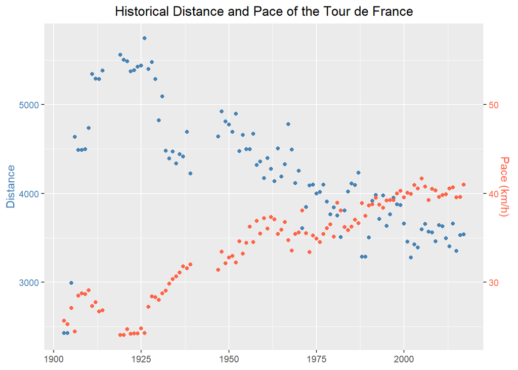

The Tour de France had undergone a variety of organizational changes through the years, especially during the decade. The first few Tours were quite the short race. As its popularity soared, we can see that there was a massive increase in the distance of the race in 1906. This increase in distance actually made it possible for the race route to closely follow the borders of France.

As time passed, however, the Tour actually decreased in distance. The modern Tour no longer follows the borders of France. It not only includes stages in nearby countries, but also includes bus trips and plane rides between stages to that commence in cities different from the destination of the previous stage.

We can also see that the pace of the winning cyclist has been increasing through the years as well. The fastest pace ever set was by Lance Armstrong, who rode 3,592.5 km in 86h 15’ 02" at a pace of 41.7 km/h. This nearly two times faster than the slowest winning pace of 24.1 km/h, set by Firmin Lambot in 1919. It’s not clear whether the faster paces were made possible by the shorter races, but it is an interesting correlation to notice.

Note the blank during the two World Wars: 1915-1918 (WWI) and 1940-1946 (WWII). The Tour de France was not held during these years.

#### More Cyclists Competing in the Tour de France are Finishing the Race

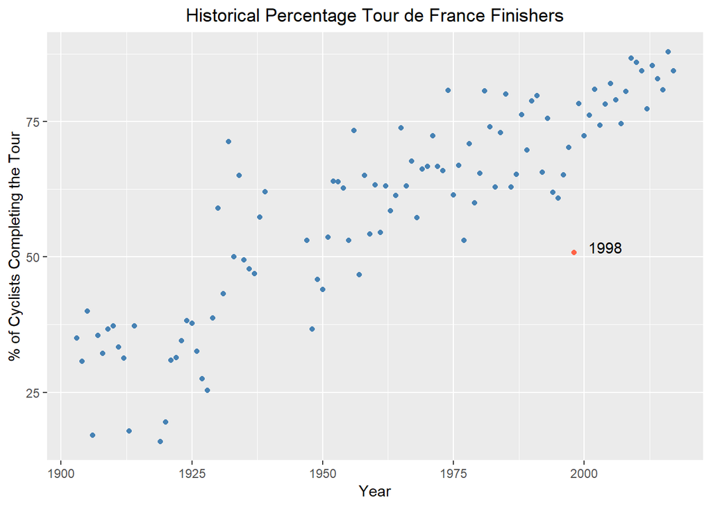

In the early days of the Tour de France, cyclists could fail to finish a tour for a variety of reasons: disqualification due to cheating by taking a train instead of cycling, falling asleep at the side of the road, and (of course) injuries. There are more rules that can lead to elimination in the modern day tour. Doping and taking performance enhancement drugs is an obvious one. Another rule would be that participants must finish within a certain percentage of time from the stage winner to avoid elimination.

As the years pass, more and more participating cyclists tend to finish the whole tour. We do notice on exception in the 1998 Tour, where only marginally more than half the participants managed to complete the race. What happened?

**The 1998 Tour de France**  
Longtime Tour watchers would immediately recognize this Tour as the “Tour du Dopage” as well as the year of the Festina affair. Two full teams, Festina and TVM were expelled due to evidence retrieved from police involvement. The final mountain stage, Stage 17, was annulled due to a rider’s strike, during which many more teams decided to abandom the race. Ultimately, with 7 out of 21 full teams departing the Tour, it is no surprise that the percent of finishing riders in 1998 was so low.

#### France is the Most Decorated Country (Unsurprisingly)

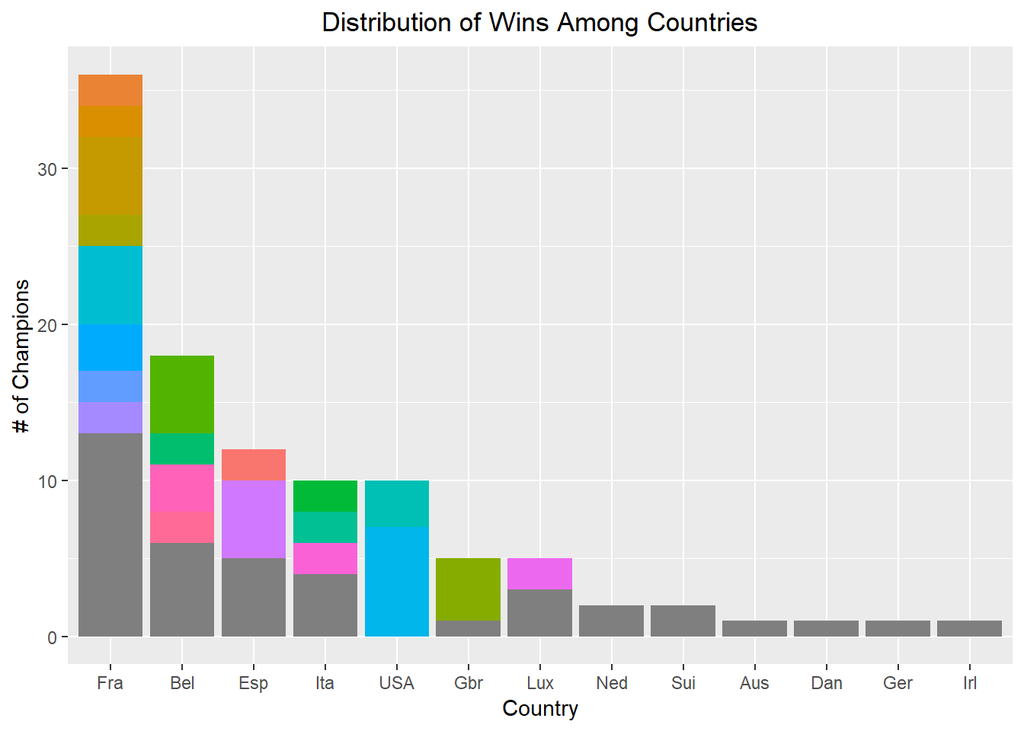

Unsurprisingly, France has the most Tour de France champions (36), with Belgium (18) coming in second and Spain (12) in third. We note that the majority of Tour wins can be accounted for by multiyear champions alone. In fact, looking at the USA, we see that all of the wins can be accounted for by two individuals, Lance Armstrong and Greg LeMond.

### Tour de France By Stages

The overall Tour de France is won by the cyclist that has the fastest culmulative time. However, there the fastest rider of each stage is still wildly celebrated and their wins contribute to the points classification as well as the team classification. Here, we take a closer look at the Tour de France Stage Winners.

#### Stage Wins Ranking Differ from Tour Wins Ranking

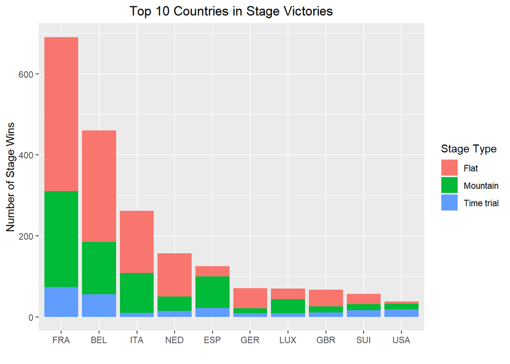

Once again, France has is the most decorated country in terms of stage wins with Belgium in second place. While Spain came in third in terms of Tour wins, it was fifth in terms of Stage wins. The Netherlands, which had won 2 Tours total, had won 157 Stages. On the other hand, if we still count the 7 Tour titles by Lance Armstrong, the USA had won 10 Tours while only winning 38 Stages. Winning more stages certainly makes it more likely to win the Tour, it seems that there is some wiggle room in the absolute rankings.

We also note that an unusually large portion of Spain’s victories come from Mountain Stages. Perhaps there’s something about Spanish racers make them particularly formidable opponents on climbs?

#### ~130 Cyclists are Responsible for Over Half of All Stage Victories

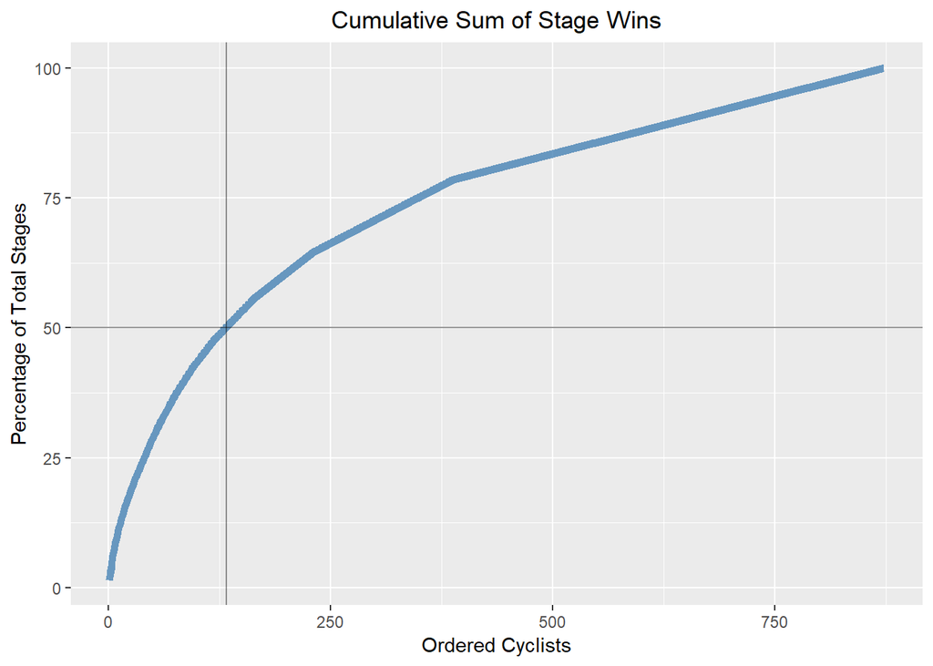

When we plot the cumulative sum of the stage wins, we can see that around 130 cyclists can account for more than 50% of all the stages won during the Tour de France. Furthermore, we see that riders who have won a single stage only account for less than 25% of all stages.

Now, let’s hone in on the most decorated riders.

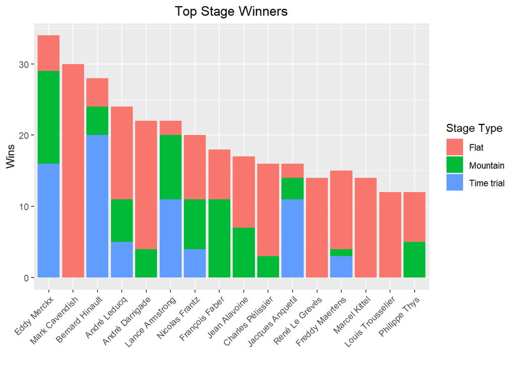

Eddy Merckx is the most decorated rider with a whopping total of 34 stage wins. Furthermore, we notice that the majority of riders specialize in only two, if not one, of the three different stage categories. However, Eddy managed to win stages of all types. Other well-rounded cyclests include Bernard Hinault, André Leducq, Lance Armstrong, Nicolas Frantz, Jacques Anquetil, and Freddy Maertens. With the exception of Maertens, the remaining other all-rounder cyclists have all won the Tour de France during their career. Perhaps that is an indication that in order to win the Tour, one has to be outstanding across a variety of terrains.

**Records**  
Most Flat Stage Wins: *Mark Cavendish*  
Most Mountain Stage Wins: *Eddy Merckx*  
Most Time Trial Stage Wins: *Bernard Hinault*

#### Stage Distances Have Also Shortened Over the Years

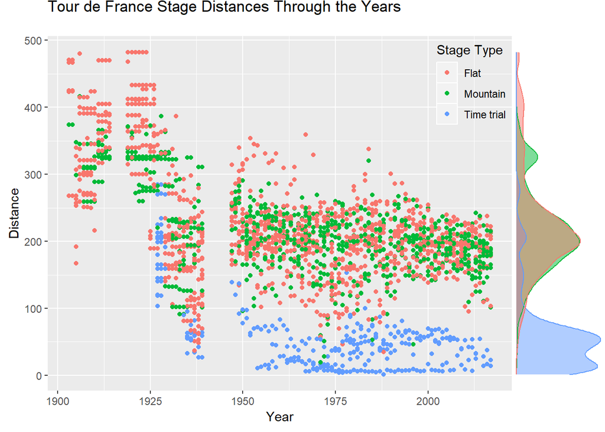

We already knew that over the years, the total distance covered in the Tour de France has decreased. But what about on the individual stage level? Have stage distances decreased as well? It turns out, yes, they have. Every single stage type has decreased in length since the beginning of the Tour de France.

From the density plot on the right, we can see that generally, Time Trial Stages are the shortest, while Flat and Mountain Stages are comparable in length. We see that there is a small bump representing very long Mountain Stages that appears like an outlier. Upon closer inspection, we realize that long Mountain Stages are a relic of the past, occuring nearly exclusively before ~1930. During this time period, Time Trials were also much longer than modern day Trials.

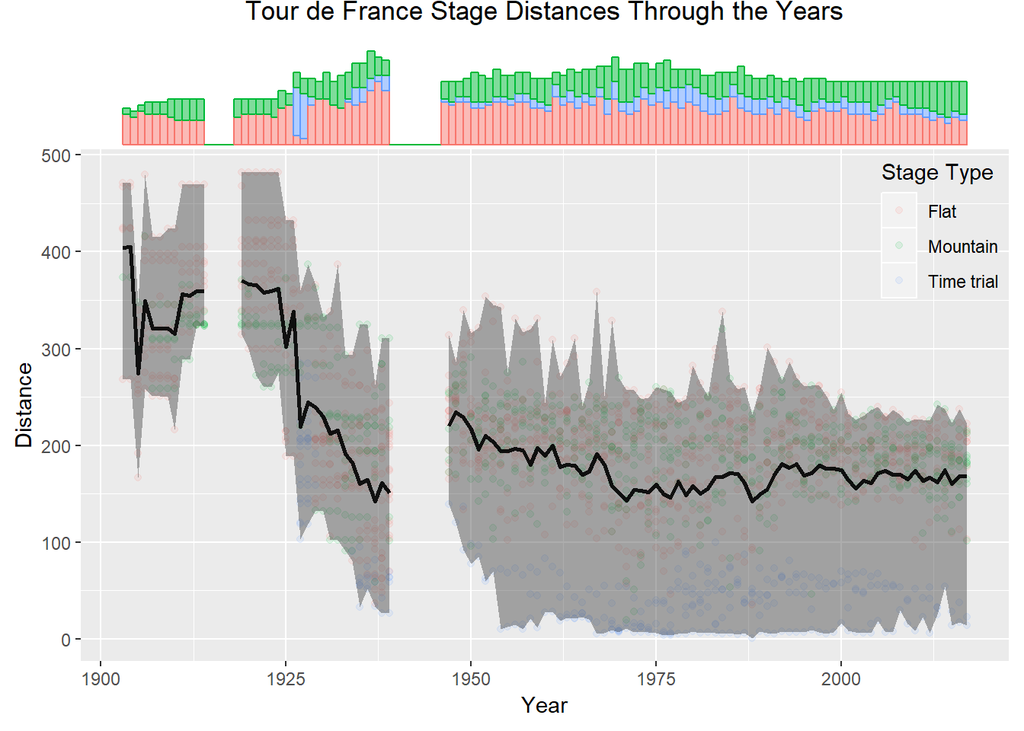

We can also look at the distribution of stage types across the years. We see that when the Tour first began, there were very few stages, each being incredibly long. We also notice that Time Trial Stages were not actually introduced until 1927, when they became the most common stage. This persisted for one more year before they once again became the rarest stage. In recent years, the Tour de France has consisted of 21 stages. The average stage length (denoted by the black line) as well as minimum and maximum stage length (denoted by the grey ribbon) has been consistent as well.

#### Popular Cities Visited during the Tour de France

[figure not shown]

Unsurprisingly, we see a big, opaque cluster of red around Paris. The capital of France is a highly popular starting point as well as ending point for various stages in the Tour de France. Furthermore, many flat stage time trials take place in this city. How exciting!

We also notice various red dots in other courtries such as Belgium, Switzerland, and Italy. Over the years, the Tour de France has held stages in many neighboring countries. Upon closer inspection, we also notice a big cluster of red dots around the border of France, Switzerland, and Italy, on the patch of green. What could possibly be this popular stage location?

It turns out this is where the famous Alpe d’Huez is located! This location has been used as a mountain stage in the Tour de France (even twice in the same day in 2013!) This famous climb has an average gradient of 8.1%, maximum gradient of 13%, and is a 13.8 km climb through 21 hairpin turns (named after the winner of stages) up to a the summit at 1860 meters.

**Records**  
Fastest Alpe d’Huez Ascent: *Alberto Contador (37’ 30“) during the 2010 Critérium du Dauphiné.*  
First Alpe d’Huez Stage Winner: *Fausto Coppi (1952)*

### Conclusion and Next Steps

It’s so interesting to see historial events emerge as outliers from this whirlwind tour of the history of the Tour de France. From identifying winners to looking at distance and stage trends, we can see that the Tour de France today is a very different race from the one that was started in 1903.

In the future, I would love to look in more detail about each individual cyclist’s performance and look for trends through the years. From what I understand, this data can be scraped from the [Official Tour de France website](https://www.letour.fr/en/history). This has been done by Thomas Camminady as stated on his [website](https://www.camminady.org/every-cyclist-of-the-tour-de-france-in-a-single-csv-file/). When I get a chance, I would love to do some exploratory data analysis on this dataset.

### Final Note

I was inspired to work on a Tour de France dataset thanks to the documentary “**Eat, Race, Win**”. As someone very new to the sport of cycling, the Tour de France, I am sure there are mistakes in my interpretations. Any advice, suggestions, or corrections are welcomed!

It seems that I am having trouble with Kaggle’s RMarkdown in getting ggExtra to update to v0.8, as well as trouble with geocode in getting a map to visualized. In this case, I simply enclosed an image of what the visualization should have looked like. To recreate these visualizations, the script should work (just not on Kaggle). Alternatively, for all the information regarding this analysis, please visit [my github](https://github.com/jamminliu/Tour-de-France-Exploration)

**Sources:**  
[Wikipedia](https://en.wikipedia.org/wiki/Tour_de_France)  
[Le Tour de France Official Website](https://www.letour.fr/en/history)  
[Stage Details Dataset](https://www.kaggle.com/ralle360/historic-tour-de-france-dataset) by RasmusFiskerBang on Kaggle